# Case study 3: Interpretable ensemble models for differential expression analysis of Microbiome data

Jialin Gao

2025-03-21

This vignette highlights the example workflow for performing differential expression using interpretable ensemble models with a microbiome dataset.

## Install and load packages

```r
# Clear workspace
rm(list = ls())
#install.packages(c("lme4", "dplyr"))
library(lme4)
library(dplyr)
library(readr)
library(foreach)
library(doParallel)
library(Maaslin2)
library(ANCOMBC)
library(TreeSummarizedExperiment)
library(S4Vectors)
library(ANCOMBC)
library(tibble)
library(MicrobiomeStat)
library(DAssemble)
library(cowplot)
library(ggplot2)
library(vegan)
library(plyr)
library(LOCOM)
library(DESeq2)
library(edgeR)
library(LOCOM)
library(ALDEx2)
library(ggplot2)
library(writexl)
library(stringr)

#BiocManager::install("ALDEx2")
library(ANCOMBC)
library(TreeSummarizedExperiment)

package_vec = c("reshape2", "ggplot2", "optparse",
                "parallel", "stringi", "doParallel", "plyr", "tidyr", 'dplyr', 'vegan',
                'Maaslin2','ALDEx2')
loaded_packages <- intersect(package_vec, .packages())

library(here)
# Load Source Files
setwd(here::here())
#pkgmaker::source_files('./Codes/Real_Data/helper', '*.R')
```

## Data Loading and Preprocessing

The Preprocssing step is same with MaAsLin3 benchmark https://github.com/WillNickols/maaslin3_benchmark/tree/main/HMP2/analysis/run_scripts

```r
# Manually define directories and parameters (for RStudio use)
workingDirectory <- "~/Desktop/DAssemble"
analysisDirectory <- "~/Desktop/DAssemble"

nCores <- 6  # Adjust based on your system
dataset <- "taxa"  # Choose 'taxa'
version <- 4  # Set MetaPhlAn version (3 or 4)

# Load MetaPhlAn data
if (version == 3) {
    taxa_table <- read.csv('~/Desktop/DAssemble/Codes/Dataset/metaphlan3_taxonomic_profiles.tsv', check.names = FALSE, sep = '\t')
    taxa_table <- taxa_table[grepl('\\|s__', taxa_table$`#SampleID`), ]  # Fixed escaping issue
    rownames(taxa_table) <- taxa_table$`#SampleID`
    taxa_table$`#SampleID` <- NULL
    taxa_table <- taxa_table * 100 # Convert to percentage
} else if (version == 4) {
    taxa_table <- read.csv('~/Desktop/DAssemble/Codes/Dataset/metaphlan4_taxonomic_profiles.tsv', skip = 1, check.names = FALSE, sep = '\t')
    colnames(taxa_table) <- gsub('_taxonomic$', '', colnames(taxa_table))
    taxa_table <- taxa_table[grepl('\\|t__', taxa_table$clade_name), ]  # Fixed escaping issue
    rownames(taxa_table) <- taxa_table$clade_name
    taxa_table$clade_name <- NULL
} else {
    stop("Invalid MetaPhlAn version")
}

prepare_metadata <- function(dataset_type) {
    metadata <- read.csv('~/Desktop/DAssemble/Codes/Dataset/hmp2_metadata_2018-08-20.csv', check.names = F)

    # Reorganize metadata table
    for (participant_id in unique(metadata$`Participant ID`)) {
        bmis <- metadata$BMI[metadata$`Participant ID` == participant_id]
        bmis <- bmis[!is.na(bmis)]
        metadata$BMI[metadata$`Participant ID` == participant_id] <- ifelse(length(bmis) > 0, mean(bmis), NA)

        smoke_status <- metadata$`smoking status`[metadata$`Participant ID` == participant_id]
        smoke_status <- smoke_status[!is.na(smoke_status)]
        metadata$`smoking status`[metadata$`Participant ID` == participant_id] <- ifelse(length(smoke_status) > 0, smoke_status[1], NA)
    }

    if (dataset_type == 'taxa') {
        metadata <- metadata[metadata$data_type == 'metagenomics',]
    } else {
        metadata <- metadata[metadata$data_type == 'metabolomics',]
    }
    rownames(metadata) <- metadata$`External ID`
    metadata <- metadata[,colSums(metadata == '', na.rm = T) != nrow(metadata)]
    keep_cols <- c('External ID', 'Participant ID', 'week_num', 'site_name', 'Age at diagnosis',
                   'Education Level', 'Occupation', 'consent_age', 'diagnosis',
                   colnames(metadata)[c(52:83, 85:111)], 'race', 'sex', 'BMI', 'reads_filtered')
    metadata <- metadata[,keep_cols]
    metadata <- metadata[,colSums(!is.na(metadata)) != 0]
    return(metadata)
}
metadata <- prepare_metadata('taxa')

# Calculate dysbiosis score
veg_dist_out <- vegdist(t(as.matrix(taxa_table)), method="bray")
```

```r
veg_dist_out <- as.matrix(veg_dist_out)
dysbiosis_scores <- vector(length = nrow(veg_dist_out))
for (i in seq_along(rownames(veg_dist_out))) {
    sample_name <- rownames(veg_dist_out)[i]
    healthy_subset <- colnames(taxa_table)[colnames(taxa_table) %in%
                                               rownames(metadata[metadata$week_num > 20 &
                                                                     metadata$diagnosis == 'nonIBD' &
                                                                     metadata$`Participant ID` != metadata[sample_name,]$`Participant ID`,])]

    dysbiosis_scores[i] <- median(veg_dist_out[sample_name, healthy_subset])
}
names(dysbiosis_scores) <- rownames(veg_dist_out)

# Add the dysbiosis state to the metadata
dysbiosis_df <- data.frame(sample=names(dysbiosis_scores), dysbiosis_score=dysbiosis_scores)
metadata <- right_join(dysbiosis_df, metadata, by=c('sample'='External ID'))
metadata$dysbiosis_state <- metadata$dysbiosis_score > quantile(metadata$dysbiosis_score[metadata$diagnosis == 'nonIBD'], 0.9, na.rm=T)
metadata$dysbiosis_state <- ifelse(metadata$dysbiosis_state, paste0('dysbiosis_', metadata$diagnosis), 'none')
metadata$dysbiosis_state <- factor(metadata$dysbiosis_state, levels = c('none', 'dysbiosis_nonIBD', 'dysbiosis_UC', 'dysbiosis_CD'))

dysbiosis_df <- metadata[, c("sample", "dysbiosis_state")]
dysbiosis_df <- dysbiosis_df[order(dysbiosis_df$sample),]
dysbiosis_df <- dysbiosis_df[!duplicated(dysbiosis_df$sample),]

metadata <- prepare_metadata(dataset)
metadata <- right_join(dysbiosis_df, metadata, by=c('sample'='External ID'))

metadata$participant_id <- metadata$`Participant ID`
metadata$diagnosis <- factor(ifelse(metadata$diagnosis %in% c("CD", "UC"), "IBD", "nonIBD"),
                             levels = c("nonIBD", "IBD"))


metadata <- metadata[!is.na(metadata$dysbiosis_state),]
rownames(metadata) <- metadata$sample

if (dataset == 'taxa') {
    if (version == 3) {
        taxa_table <- read.csv('~/Desktop/DAssemble/Codes/Dataset/metaphlan3_taxonomic_profiles.tsv',check.names = F, sep = '\t')
        taxa_table <- taxa_table[grepl('\\|s__', taxa_table$`#SampleID`) &
                         !grepl('\\|t__', taxa_table$`#SampleID`) &
                         taxa_table$`#SampleID` != 'UNCLASSIFIED',]
        rownames(taxa_table) <- taxa_table$`#SampleID`
        taxa_table$`#SampleID` <- NULL
        taxa_table['UNCLASSIFIED',] <- pmax(1 - colSums(taxa_table), 0)
        taxa_table <- taxa_table * 100 # Convert to percents to be consistent with v4
    } else if (version == 4) {
        taxa_table <- read.csv('~/Desktop/DAssemble/Codes/Dataset/metaphlan4_taxonomic_profiles.tsv', skip = 1, check.names = F, sep = '\t')

        # Reorganize taxa table
        colnames(taxa_table) <- gsub('_taxonomic$', '', colnames(taxa_table))
        # taxa_table <- taxa_table[taxa_table$clade_name == 'UNCLASSIFIED' |
        #                              grepl('\\|t__', taxa_table$clade_name),]
        taxa_table <- taxa_table[grepl('\\|t__', taxa_table$clade_name) &
                         taxa_table$clade_name != 'UNCLASSIFIED',]
        rownames(taxa_table) <- taxa_table$clade_name
        taxa_table$clade_name <- NULL
    } else {
        stop("--version not valid")
    }

} else {
    # Read in data
    mbx_table <- read.csv("~/Desktop/DAssemble/Codes/Dataset/intensities_hmp2.csv")
    annotations <- read.csv("~/Desktop/DAssemble/Codes/Dataset/annotations_hmp2.csv")

    if (all(abs(annotations$prev - rowMeans(!is.na(mbx_table))) < 0.001)) {
        mbx_table <- mbx_table[annotations$prim_feature == 'primary' & annotations$Metabolite != '',]
        rownames(mbx_table) <- paste0(annotations$Metabolite[annotations$prim_feature == 'primary' & annotations$Metabolite != ''], '_',
                                      annotations$HMDB.ID[annotations$prim_feature == 'primary' & annotations$Metabolite != ''], '_',
                                      annotations$Method[annotations$prim_feature == 'primary' & annotations$Metabolite != ''])
        mbx_table[is.na(mbx_table)] <- 0
    }
    taxa_table <- mbx_table
}

metadata <- metadata[metadata$sample %in% colnames(taxa_table),]
metadata <- metadata[as.numeric(mapvalues(metadata$sample, colnames(taxa_table), 1:ncol(taxa_table))),]
```

On the basis of same preprocessing as MaAsLin3, we further shorten feature names and subset the dataset to baseline to make model fitting easier.

```r
rownames(taxa_table) <- gsub("^.*\\|s__", "s__", rownames(taxa_table))

# Step 1: Extract baseline subjects from metadata
baseline_metadata <- metadata %>%
  distinct(participant_id, .keep_all = TRUE) %>%
  filter(week_num < 3)  # Only subjects with week_num < 3


baseline_samples <- baseline_metadata$sample
baseline_taxa_table <- taxa_table[, colnames(taxa_table) %in% baseline_samples, drop = FALSE]

cat("Dimensions of baseline_metadata:", dim(baseline_metadata), "\n")
```

```
#> Dimensions of baseline_metadata: 94 61
```

```r
cat("Subsetted Taxa Table Dimensions (samples × features):", dim(baseline_taxa_table), "\n")
```

```
#> Subsetted Taxa Table Dimensions (samples × features): 1789 94
```

```r
taxa_table <- baseline_taxa_table
metadata <- baseline_metadata
```

## Run models

Here, we fit the two part model using MaAsLin2 and Logistic Regression. First, we fit the models separately and then combine the two-part model using the p-value combination method.

## Run MaAsLin2

```r
if (dataset == 'taxa') {
    if (version == 3) {
        tmp_fit_out <- paste0(gsub("/$", "", analysisDirectory), "/fit_out_MaAsLin2_3")
    } else {
        tmp_fit_out <- paste0(gsub("/$", "", analysisDirectory), "/fit_out_MaAsLin2_4")
    }
} else {
    tmp_fit_out <- paste0(gsub("/$", "", analysisDirectory), "/fit_out_MaAsLin2_mbx")
}

if (dataset == 'taxa') {
  fit_out <- Maaslin2::Maaslin2(taxa_table, metadata,
                                min_abundance = 0,
                                min_prevalence = 0,
                                output = tmp_fit_out,
                                min_variance = 0,
                                normalization = 'TSS',
                                transform = 'log',
                                analysis_method = 'LM',
                                fixed_effects = c('diagnosis', 'Antibiotics', 'consent_age'),
                                save_scatter = FALSE,
                                save_models = F,
                                plot_heatmap = F,
                                plot_scatter = F,
                                max_significance = 0.1,
                                reference = 'diagnosis,nonIBD')$results
} else {
  fit_out <- Maaslin2::Maaslin2(taxa_table,
                                metadata,
                                min_abundance = 0,
                                min_prevalence = 0,
                                output = tmp_fit_out,
                                min_variance = 0,
                                normalization = 'NONE',
                                transform = 'log',
                                analysis_method = 'LM',
                                fixed_effects = c('diagnosis', 'Antibiotics', 'consent_age'),
                                save_scatter = FALSE,
                                ave_models = F,
                                plot_heatmap = F,
                                plot_scatter = F,
                                max_significance = 0.1,
                                reference = 'diagnosis,nonIBD')$results
}

unlink(tmp_fit_out, recursive = T)


fit_out <- data.frame(feature = fit_out$feature,
           metadata = fit_out$metadata,
           value = fit_out$value,
           coef = fit_out$coef,
           pval = fit_out$pval,
           qval = fit_out$qval,
           association = "abundance")

fit_out <- fit_out[fit_out$metadata == "diagnosis", ]
fit_out$qval <- p.adjust(fit_out$pval, method = "BH")


paras_CR <- fit_out
paras_CR <- paras_CR %>%
  dplyr::rename(
    coef_CR = coef,
    pval_CR = pval,
    qval_CR = qval
  ) %>%
  dplyr::mutate(
    metadata = "diagnosis"
  ) %>%
  dplyr::select(
    feature,
    coef_CR,
    pval_CR,
    qval_CR,
    metadata
  )
#write.table(paras_CR, paste0(gsub("/$", "", analysisDirectory), "/results/", ifelse(dataset == 'taxa', '', 'mbx_'), "v", version, "_ibd_associations_MaAsLin2.tsv"), row.names = F, sep='\t')
```

## Run Logistic Regression

```r
taxa_table <- as.data.frame(t(baseline_taxa_table))
metadata <- as.data.frame(baseline_metadata)
input_features <- taxa_table
input_metadata <- metadata
results_list <- list()

for (x in 1:ncol(input_features)) {

    feature_name <- colnames(input_features)[x]
    featuresVector <- input_features[, x]
    featuresVector <- as.factor(ifelse(featuresVector != 0, 1, 0))
    dat_sub <- data.frame(expr = featuresVector, metadata)
    formula <- as.formula("expr ~ diagnosis + consent_age + Antibiotics")

    fit <- tryCatch({
      glm(formula = formula, data = dat_sub, family = "binomial")
    }, error = function(err) {
      try(lme4::glmer(formula = formula, data = dat_sub, family = "binomial",
                      control = glmerControl(optimizer = "bobyqa", optCtrl = list(maxfun = 1e5))))
    })

    if (!inherits(fit, "try-error")) {
        para <- as.data.frame(summary(fit)$coefficients[, c(1, 2, 4), drop = FALSE])
    } else {
        para <- as.data.frame(matrix(NA, nrow = 1, ncol = 3))
        colnames(para) <- c("Estimate", "Std. Error", "Pr(>|z|)")
        print(paste("Fitting problem for feature", feature_name, "returning NA"))
    }

    para$feature <- feature_name
    results_list[[feature_name]] <- para
}

results_df <- do.call(rbind, results_list)
results_df$variable <- rownames(results_df)
diagnosis_subset <- results_df[grep("diagnosis", results_df$variable, ignore.case = TRUE), ]
diagnosis_subset$qval_LR <- p.adjust(diagnosis_subset$`Pr(>|z|)`, method = "BH")

paras_LR <- diagnosis_subset

paras_LR <- paras_LR %>%
  dplyr::mutate(
    metadata = "diagnosis"
  ) %>%
  dplyr::select(
    feature,
    coef_LR = Estimate,
    pval_LR = `Pr(>|z|)`,
    qval_LR,
    metadata
  )

rownames(paras_LR) <- NULL

print(paras_LR)
#write.table(paras_LR, paste0(gsub("/$", "", analysisDirectory), "/results/", ifelse(dataset == 'taxa', '', 'mbx_'), "v", version, "_ibd_associations_LogisticRegression.tsv"), row.names = F, sep='\t')
```

## Combine results

After running MaAsLin2 and Logistic Regression, we use CC, MC and SC to combine p-values and calculate q-values based on combined p-values. We can use the DAssemble() from library(DAssemble) for this step.

```r
paras_CR <- paras_CR %>%
  dplyr::mutate(ID = gsub("\\.t__", "|t__", feature))  %>%
  dplyr::rename(pvalue = pval_CR)

paras_LR <- paras_LR %>%
  dplyr::mutate(ID = feature) %>%
  dplyr::rename(pvalue = pval_LR)

## MaAsLin2
dflist1 = list(paras_LR, paras_CR)
## MC
parasVanilla_MaAsLin2 = DAssemble(dflist1, combine.method = "minP", correction = "BH")
parasVanilla_MaAsLin2[1:10, ]
```

```
#>                                                            ID
#> 253                     s__Clostridium_sp_AM49_4BH|t__SGB4652
#> 682                          s__GGB79973_SGB14341|t__SGB14341
#> 8                  s__Adlercreutzia_equolifaciens|t__SGB14797
#> 195          s__Clostridiaceae_bacterium_AF18_31LB|t__SGB4767
#> 205                    s__Clostridiaceae_bacterium|t__SGB4770
#> 961  s__Oscillospiraceae_bacterium_Marseille_Q3528|t__SGB4778
#> 1099                  s__Sutterella_wadsworthensis|t__SGB9283
#> 186       s__Christensenellaceae_bacterium_NSJ_63|t__SGB14127
#> 165    s__Candidatus_Gastranaerophilales_bacterium|t__SGB8601
#> 224    s__Clostridiales_Family_XIII_bacterium_BX16|t__SGB3957
#>                                                     feature.x    coef_LR
#> 253                     s__Clostridium_sp_AM49_4BH|t__SGB4652  -1.918830
#> 682                          s__GGB79973_SGB14341|t__SGB14341  -3.290448
#> 8                  s__Adlercreutzia_equolifaciens|t__SGB14797 -20.078604
```

[output cut: 41 more lines]

```r
parasCCT_MaAsLin2 = DAssemble(dflist1, combine.method = "CCT", correction = "BH")
parasCCT_MaAsLin2[1:10, ]
```

```
#>                                                            ID
#> 253                     s__Clostridium_sp_AM49_4BH|t__SGB4652
#> 682                          s__GGB79973_SGB14341|t__SGB14341
#> 195          s__Clostridiaceae_bacterium_AF18_31LB|t__SGB4767
#> 205                    s__Clostridiaceae_bacterium|t__SGB4770
#> 961  s__Oscillospiraceae_bacterium_Marseille_Q3528|t__SGB4778
#> 1099                  s__Sutterella_wadsworthensis|t__SGB9283
#> 8                  s__Adlercreutzia_equolifaciens|t__SGB14797
#> 186       s__Christensenellaceae_bacterium_NSJ_63|t__SGB14127
#> 252                       s__Clostridium_sp_AM33_3|t__SGB4711
#> 882         s__Lachnospiraceae_bacterium_AM48_27BH|t__SGB4706
#>                                                     feature.x    coef_LR
#> 253                     s__Clostridium_sp_AM49_4BH|t__SGB4652  -1.918830
#> 682                          s__GGB79973_SGB14341|t__SGB14341  -3.290448
#> 195          s__Clostridiaceae_bacterium_AF18_31LB|t__SGB4767  -2.265582
```

[output cut: 41 more lines]

```r
parasStouffer_MaAsLin2 = DAssemble(dflist1, combine.method = "stouffer", correction = "BH")
parasStouffer_MaAsLin2[1:10,]
```

```
#>                                                            ID
#> 195          s__Clostridiaceae_bacterium_AF18_31LB|t__SGB4767
#> 253                     s__Clostridium_sp_AM49_4BH|t__SGB4652
#> 682                          s__GGB79973_SGB14341|t__SGB14341
#> 205                    s__Clostridiaceae_bacterium|t__SGB4770
#> 961  s__Oscillospiraceae_bacterium_Marseille_Q3528|t__SGB4778
#> 252                       s__Clostridium_sp_AM33_3|t__SGB4711
#> 882         s__Lachnospiraceae_bacterium_AM48_27BH|t__SGB4706
#> 267                       s__Collinsella_SGB14861|t__SGB14861
#> 1099                  s__Sutterella_wadsworthensis|t__SGB9283
#> 29                             s__Alistipes_shahii|t__SGB2295
#>                                                     feature.x   coef_LR
#> 195          s__Clostridiaceae_bacterium_AF18_31LB|t__SGB4767 -2.265582
#> 253                     s__Clostridium_sp_AM49_4BH|t__SGB4652 -1.918830
#> 682                          s__GGB79973_SGB14341|t__SGB14341 -3.290448
```

[output cut: 40 more lines]

## Compare results

To compare Logistic Regression and models using different combination methods, we create plots to highlight key microbial taxa associated with IBD through combined abundance and prevalence modeling. Using MaAsLin2 + LR (SC) as a representative method, we identified two major classes of IBD-associated taxa: 1) exhibiting both broad compositional shifts and presence-absence patterns (Fig. 6A); and 2) prevalence associations not detected by abundance modeling alone (Fig. 6B).

## Example: MaAsLin2 + LR (SC)

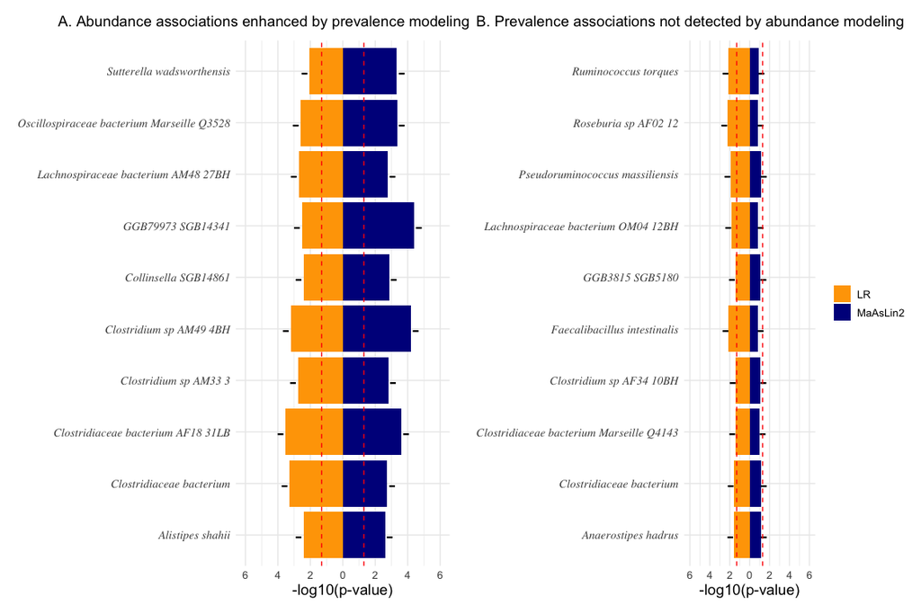

```r
threshold <- 0.25

# Extract significant species from non-ensemble model (MaAsLin2 - Original)
sig_non_ensemble <- paras_CR %>%
  filter(qval_CR < threshold) %>%
  dplyr::select(ID, qval_CR, pvalue, coef_CR) %>%
  mutate(Method = "Original")

# Extract significant species from ensemble models (CC, SC, MC)
sig_ensemble <- bind_rows(
  parasCCT_MaAsLin2 %>% mutate(Method = "CC"),
  parasStouffer_MaAsLin2 %>% mutate(Method = "SC"),
  parasVanilla_MaAsLin2 %>% mutate(Method = "MC")
) %>%
  filter(qval_BH < threshold)

sig_SC <- sig_ensemble %>%
  filter(Method == "SC") %>%
  arrange(qval_BH)

common_species <- inner_join(sig_non_ensemble, sig_SC, by = "ID") %>%
  arrange(qval_BH) %>%
  slice_head(n = 10)

# Select species significant in SC but NOT in non-ensemble
only_ensemble <- sig_SC %>%
  anti_join(sig_non_ensemble %>% filter(qval_CR < threshold), by = "ID") %>%
  arrange(desc(pvalue2))%>%
  slice_head(n = 10)

top_10 <- common_species %>%
  mutate(
    feature = ID,
    pval_CR_log10 = -log10(pvalue2),
    pval_LR_log10 = -log10(pvalue1),
    coef_CR_sign = ifelse(coef_CR.x > 0, "+", "-"),
    coef_LR_sign = ifelse(coef_LR > 0, "+", "-")
  )

top_10 <- top_10 %>%
  mutate(feature = str_replace_all(ID, "s__|\\|t__.*", "")) %>%
  mutate(feature = str_replace_all(feature, "_", " "))

only_ensemble_10 <- only_ensemble %>%
  mutate(
    feature = ID,
    pval_CR_log10 = -log10(pvalue2),
    pval_LR_log10 = -log10(pvalue1),
    coef_CR_sign = ifelse(coef_CR > 0, "+", "-"),
    coef_LR_sign = ifelse(coef_LR > 0, "+", "-")
  )

only_ensemble_10 <- only_ensemble_10 %>%
  mutate(feature = str_replace_all(ID, "s__|\\|t__.*", "")) %>%
  mutate(feature = str_replace_all(feature, "_", " "))

pval_range <- range(c(top_10$pval_CR_log10, only_ensemble_10$pval_CR_log10))
breaks_pretty_pval <- pretty(c(-max(pval_range), max(pval_range)), n = 5)

# Left Plot: Compare -log10(p-value) between MaAsLin2 and Logistic Regression (common species)
pyramid_plot_pval_1 <- ggplot(top_10) +
  geom_col(aes(x = feature, y = pval_CR_log10, fill = "MaAsLin2"), position = "identity") +
  geom_col(aes(x = feature, y = -pval_LR_log10, fill = "LR"), position = "identity") +
  geom_text(aes(x = feature, y = pval_CR_log10 + 0.3, label = coef_CR_sign), size = 7, hjust = 0.5) +
  geom_text(aes(x = feature, y = -pval_LR_log10 - 0.3, label = coef_LR_sign), size = 7, hjust = 0.5) +
  labs(y = "-log10(p-value)", x = "") +
  coord_flip() +
  theme_minimal() +
  theme(
    legend.position = "none",
    axis.title.x = element_text(size = 14),
    axis.title.y = element_text(size = 14),
    axis.text.y = element_text(size = 11, hjust = 1, face = "italic", family = "serif"),
    axis.text.x = element_text(size = 10)
  ) +
  scale_fill_manual(values = c("MaAsLin2" = "darkblue", "LR" = "orange"), name = NULL) +
  scale_y_continuous(breaks = breaks_pretty_pval, labels = abs(breaks_pretty_pval), limits = range(breaks_pretty_pval))

# Right Plot: Compare -log10(p-value) between MaAsLin2 and Logistic Regression for species found in CC but not in MaAsLin2
pyramid_plot_pval_2 <- ggplot(only_ensemble_10) +
  geom_col(aes(x = feature, y = pval_CR_log10, fill = "MaAsLin2"), position = "identity") +
  geom_col(aes(x = feature, y = -pval_LR_log10, fill = "LR"), position = "identity") +
  geom_text(aes(x = feature, y = pval_CR_log10 + 0.3, label = coef_CR_sign), size = 7, hjust = 0.5) +
  geom_text(aes(x = feature, y = -pval_LR_log10 - 0.3, label = coef_LR_sign), size = 7, hjust = 0.5) +
  labs(y = "-log10(p-value)", x = "") +
  coord_flip() +
  theme_minimal() +
  theme(
    legend.position = "right",
    axis.title.x = element_text(size = 14),
    axis.title.y = element_blank(),
    axis.text.y = element_text(size = 11, hjust = 1, face = "italic", family = "serif"),
    axis.text.x = element_text(size = 10),
    legend.text = element_text(size = 10)
  ) +
  scale_fill_manual(values = c("MaAsLin2" = "darkblue", "LR" = "orange"), name = NULL) +
  scale_y_continuous(breaks = breaks_pretty_pval, labels = abs(breaks_pretty_pval), limits = range(breaks_pretty_pval))

sig_threshold <- -log10(0.05)

pyramid_plot_pval_1 <- pyramid_plot_pval_1 +
  geom_hline(yintercept = sig_threshold, linetype = "dashed", color = "red", size = 0.5) +
  geom_hline(yintercept = -sig_threshold, linetype = "dashed", color = "red", size = 0.5)
pyramid_plot_pval_2 <- pyramid_plot_pval_2 +
  geom_hline(yintercept = sig_threshold, linetype = "dashed", color = "red", size = 0.5) +
  geom_hline(yintercept = -sig_threshold, linetype = "dashed", color = "red", size = 0.5)


# Combine both plots
combined_plot <- plot_grid(
  pyramid_plot_pval_1 +
    ggtitle("A. Abundance associations enhanced by prevalence modeling") +
    theme(plot.title = element_text(size = 14, hjust = 0.9, margin = margin(b = 10)),
          plot.margin = margin(t = 10, r = 10, b = 15, l = 1)),

  pyramid_plot_pval_2 +
    ggtitle("B. Prevalence associations not detected by abundance modeling") +
    theme(plot.title = element_text(size = 14, hjust = 0.7, margin = margin(b = 10)),
          plot.margin = margin(t = 10, r = 10, b = 1, l = 15)),

  ncol = 2,
  align = "h",
  rel_widths = c(2, 2)
)

final_plot <- plot_grid(
  ggdraw() + draw_label(
    "",
    x = 0.5, hjust = 0.5, size = 50
  ),
  combined_plot,
  ncol = 1,
  rel_heights = c(0.01, 1.2)
)

print(final_plot)
```

## Run LinDA

```r
taxa_table <- baseline_taxa_table
metadata <- baseline_metadata

input_metadata <- metadata
input_features <- taxa_table

linda_result <- linda(
  feature.dat = input_features,
  meta.dat = input_metadata,
  formula = "~ diagnosis + Antibiotics + consent_age",
  is.winsor = FALSE,
  zero.handling = "pseudo-count",
  p.adj.method = "BH",
  alpha = 0.05,
)
```

```
#> 0 features are filtered!
#> The filtered data has 89 samples and 1789 features that will be tested!
#> Warning in linda(feature.dat = input_features, meta.dat = input_metadata, : Some features have less than 3 nonzero values!
#> They have virtually no statistical power. You may consider filtering them in the analysis!
#> Pseudo-count approach is used.
#> Fit linear models ...
#> Completed.
```

```r
linda_result <- linda_result$output$diagnosisIBD
linda_result$qval <- p.adjust(linda_result$pval, method = "BH")

paras_LD <- linda_result

paras_LD <- paras_LD %>%
  tibble::rownames_to_column(var = "feature") %>%
  dplyr::rename(
    coef_LD = log2FoldChange,
    pval_LD = pvalue,
    qval_LD = qval
  ) %>%
  dplyr::mutate(
    metadata = "diagnosis"
  ) %>%
  dplyr::select(
    feature,
    coef_LD,
    pval_LD,
    qval_LD,
    metadata
  )
print(paras_LD)
# write.table(paras_LD, paste0(gsub("/$", "", analysisDirectory), "/results/", ifelse(dataset == 'taxa', '', 'mbx_'), "v", version, "_ibd_associations_LINDA.tsv"), row.names = F, sep='\t')
```

```r
paras_LD <- paras_LD %>%
  dplyr::mutate(ID = gsub("\\.t__", "|t__", feature))  %>%
  dplyr::rename(pvalue = pval_LD)

dflist2 = list(paras_LR, paras_LD)
parasCCT_LinDA = DAssemble(dflist2, combine.method = "CCT", correction = "BH")
parasCCT_LinDA[1:10, ]
```

```
#>                                                     ID
#> 294   s__Clostridiaceae_bacterium_AF18_31LB|t__SGB4767
#> 380              s__Clostridium_sp_AM49_4BH|t__SGB4652
#> 1755           s__Sutterella_wadsworthensis|t__SGB9283
#> 307             s__Clostridiaceae_bacterium|t__SGB4770
#> 1072                  s__GGB79973_SGB14341|t__SGB14341
#> 379                s__Clostridium_sp_AM33_3|t__SGB4711
#> 402                s__Collinsella_SGB14861|t__SGB14861
#> 49                      s__Alistipes_shahii|t__SGB2295
#> 851                      s__GGB3653_SGB4964|t__SGB4964
#> 1376 s__Lachnospiraceae_bacterium_AM48_27BH|t__SGB4706
#>                                              feature.x   coef_LR      pvalue1
#> 294   s__Clostridiaceae_bacterium_AF18_31LB|t__SGB4767 -2.265582 0.0002984186
#> 380              s__Clostridium_sp_AM49_4BH|t__SGB4652 -1.918830 0.0006193155
#> 1755           s__Sutterella_wadsworthensis|t__SGB9283 -1.441053 0.0088404661
```

[output cut: 31 more lines]

```r
parasVanilla_LinDA = DAssemble(dflist2, combine.method = "minP", correction = "BH")
parasVanilla_LinDA[1:10, ]
```

```
#>                                                            ID
#> 294          s__Clostridiaceae_bacterium_AF18_31LB|t__SGB4767
#> 380                     s__Clostridium_sp_AM49_4BH|t__SGB4652
#> 1755                  s__Sutterella_wadsworthensis|t__SGB9283
#> 307                    s__Clostridiaceae_bacterium|t__SGB4770
#> 1072                         s__GGB79973_SGB14341|t__SGB14341
#> 379                       s__Clostridium_sp_AM33_3|t__SGB4711
#> 402                       s__Collinsella_SGB14861|t__SGB14861
#> 1376        s__Lachnospiraceae_bacterium_AM48_27BH|t__SGB4706
#> 851                             s__GGB3653_SGB4964|t__SGB4964
#> 1505 s__Oscillospiraceae_bacterium_Marseille_Q3528|t__SGB4778
#>                                                     feature.x   coef_LR
#> 294          s__Clostridiaceae_bacterium_AF18_31LB|t__SGB4767 -2.265582
#> 380                     s__Clostridium_sp_AM49_4BH|t__SGB4652 -1.918830
#> 1755                  s__Sutterella_wadsworthensis|t__SGB9283 -1.441053
```

[output cut: 41 more lines]

```r
parasStouffer_LinDA = DAssemble(dflist2, combine.method = "stouffer", correction = "BH")
parasStouffer_LinDA[1:10,]
```

```
#>                                                            ID
#> 294          s__Clostridiaceae_bacterium_AF18_31LB|t__SGB4767
#> 380                     s__Clostridium_sp_AM49_4BH|t__SGB4652
#> 1755                  s__Sutterella_wadsworthensis|t__SGB9283
#> 1072                         s__GGB79973_SGB14341|t__SGB14341
#> 402                       s__Collinsella_SGB14861|t__SGB14861
#> 49                             s__Alistipes_shahii|t__SGB2295
#> 379                       s__Clostridium_sp_AM33_3|t__SGB4711
#> 851                             s__GGB3653_SGB4964|t__SGB4964
#> 682                             s__GGB2653_SGB3574|t__SGB3574
#> 1505 s__Oscillospiraceae_bacterium_Marseille_Q3528|t__SGB4778
#>                                                     feature.x   coef_LR
#> 294          s__Clostridiaceae_bacterium_AF18_31LB|t__SGB4767 -2.265582
#> 380                     s__Clostridium_sp_AM49_4BH|t__SGB4652 -1.918830
#> 1755                  s__Sutterella_wadsworthensis|t__SGB9283 -1.441053
```

[output cut: 40 more lines]